# Practical I

Gerko Vink & Erik-Jan van Kesteren

Statistical Programming in R

#### Exercises

The following packages are required for this practical:

```r
library(dplyr)
library(magrittr)
library(mice)
```

```r
library(ggplot2)
library(stringr)
```

and if you’d like the same results as I have obtained, you can fix the random seed

```r
set.seed(123)
```

18. **Function `plot()` is the core plotting function in `R`. Find out more about `plot()`: Try both the help in the help-pane and `?plot` in the console. Look at the examples by running `example(plot)`.**

The help tells you all about a functions arguments (the input you can specify), as well as the element the function returns to the Global Environment. There are strict rules for publishing packages in R. For your packages to appear on the Comprehensive R Archive Network (CRAN), a rigorous series of checks have to be passed. As a result, all user-level components (functions, datasets, elements) that are published, have an acompanying documentation that elaborates how the function should be used, what can be expected, or what type of information a data set contains. Help files often contain example code that can be run to demonstrate the workings.

```r
?plot
```

```
## starting httpd help server ... done
```

```
##
## plot> require(stats) # for lowess, rpois, rnorm
##
## plot> plot(cars)
```

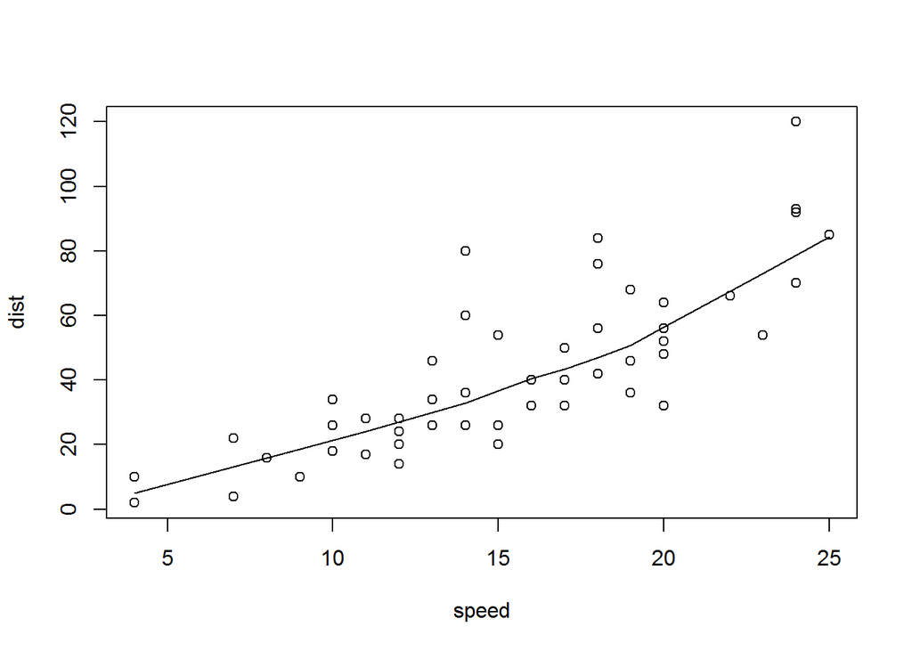

```
##
## plot> lines(lowess(cars))
##
## plot> plot(sin, -pi, 2*pi) # see ?plot.function
```

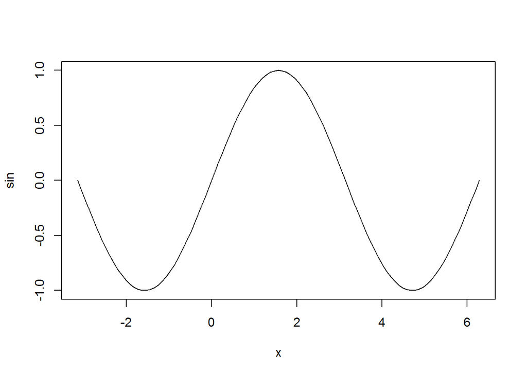

```
##
## plot> ## Discrete Distribution Plot:
## plot> plot(table(rpois(100, 5)), type = "h", col = "red", lwd = 10,
## plot+      main = "rpois(100, lambda = 5)")
```

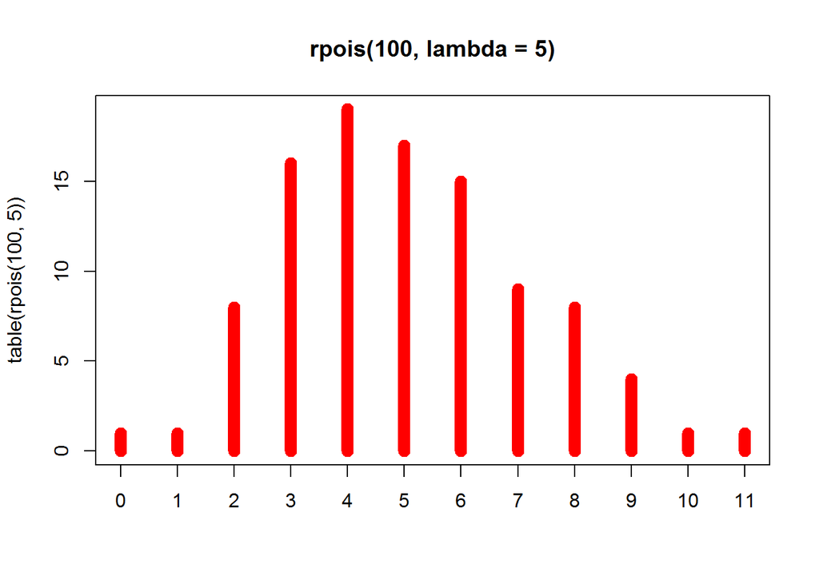

```
##
## plot> ## Simple quantiles/ECDF, see ecdf() {library(stats)} for a better one:
## plot> plot(x <- sort(rnorm(47)), type = "s", main = "plot(x, type = \"s\")")
```

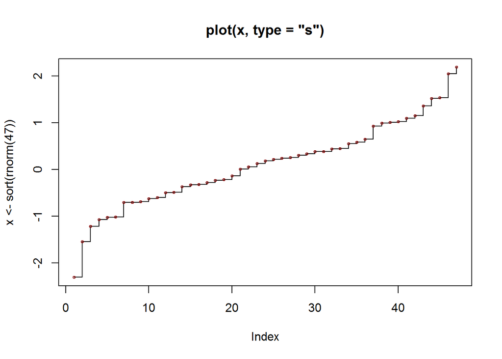

```
##
## plot> points(x, cex = .5, col = "dark red")
```

```r
example(plot)
```

There are many more functions that can plot specific types of plots. For example, function `hist()` plots histograms, but falls back on the basic `plot()` function. Packages `lattice` and `ggplot2` are excellent packages to use for complex plots. Pretty much any type of plot can be made in R. A good reference for packages `lattice` that provides all `R`-code can be found at http://lmdvr.r-forge.r-project.org/figures/figures.html. Alternatively, all ggplot2 documentation can be found at http://docs.ggplot2.org/current/

1. **Create a scatterplot between `age` and `bmi` in the `mice::boys` data set**

With the standard plotting device in `R`:

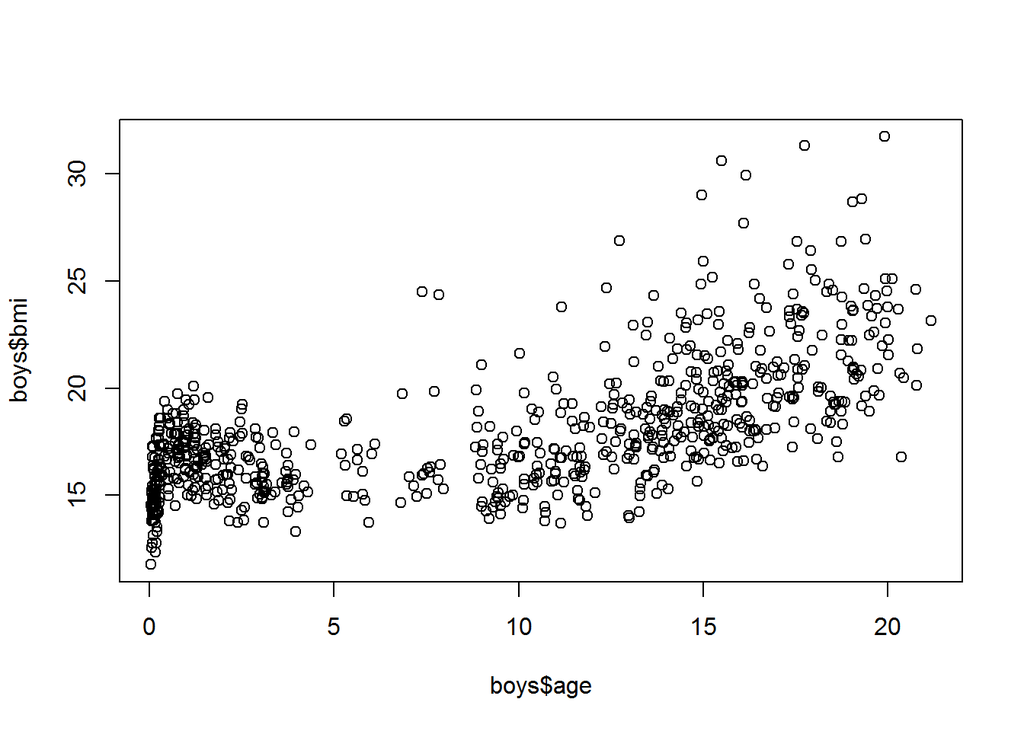

```r
plot( boys$bmi ~ boys$age )
```

2. **Now recreate the plot with the following specifications:**
- If `bmi < 18.5` use `color = "light blue"`
- If `bmi > 18.5 & bmi < 25` use `color = "light green"`
- If `bmi > 25 & bmi < 30` use `color = "orange"`
- If `bmi > 30` use `color = "red"`

Hint: it may help to expand the data set with a new variable.

It may be easier to create a new variable that creates the specified categories. We can use the `cut()` function to do this quickly

```r
boys2 <-
  boys %>%
  mutate(class = cut(bmi, c(0, 18.5, 25, 30, Inf),
                    labels = c("underweight",
                               "healthy",
                               "overweight",
                               "obese")))
```

by specifying the boundaries of the intervals. In this case we obtain 4 intervals: `0-18.5`, `18.5-25`, `25-30` and `30-Inf`. We used the `%>%` pipe to work with `bmi` directly. Alternatively, we could have done this without a pipe:

```r
boys3 <- boys
boys3$class <- cut(boys$bmi, c(0, 18.5, 25, 30, Inf),
                   labels = c("underweight",
                              "healthy",
                              "overweight",
                              "obese"))
```

to obtain the same result.

With the standard plotting device in `R` we can now specify:

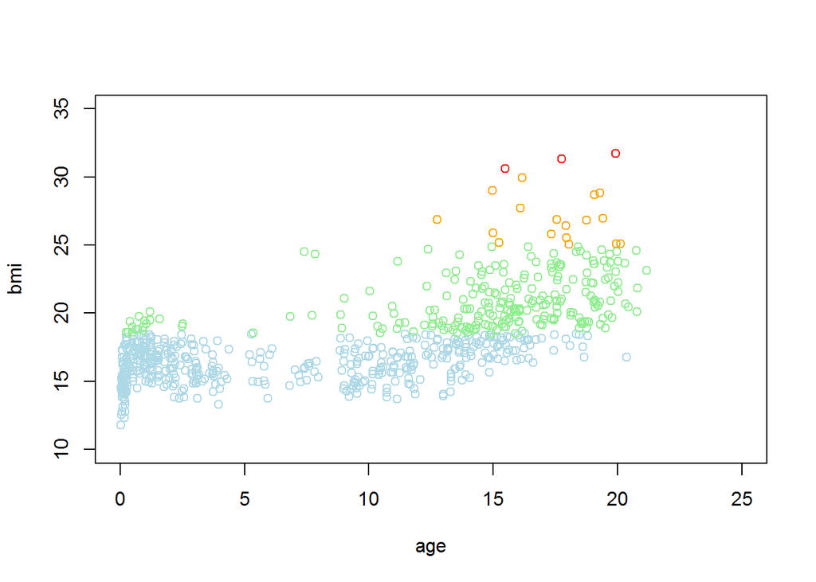

```r
plot(bmi ~ age, subset = class == "underweight", col = "light blue", data = boys2,
     ylim = c(10, 35), xlim = c(0, 25))
points(bmi ~ age, subset = class == "healthy", col = "light green", data = boys2)
points(bmi ~ age, subset = class == "overweight", col = "orange", data = boys2)
points(bmi ~ age, subset = class == "obese", col = "red", data = boys2)
```

3. **Create a histogram for `age` in the `boys` data set**

With the standard plotting device in `R`:

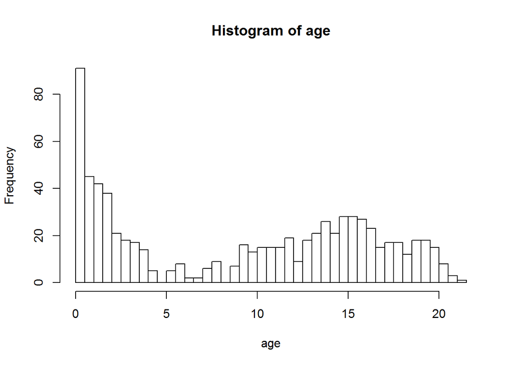

```r
boys %$%
  hist(age, breaks = 50)
```

The `breaks = 50` overrides the default breaks between the bars. By default the plot would be

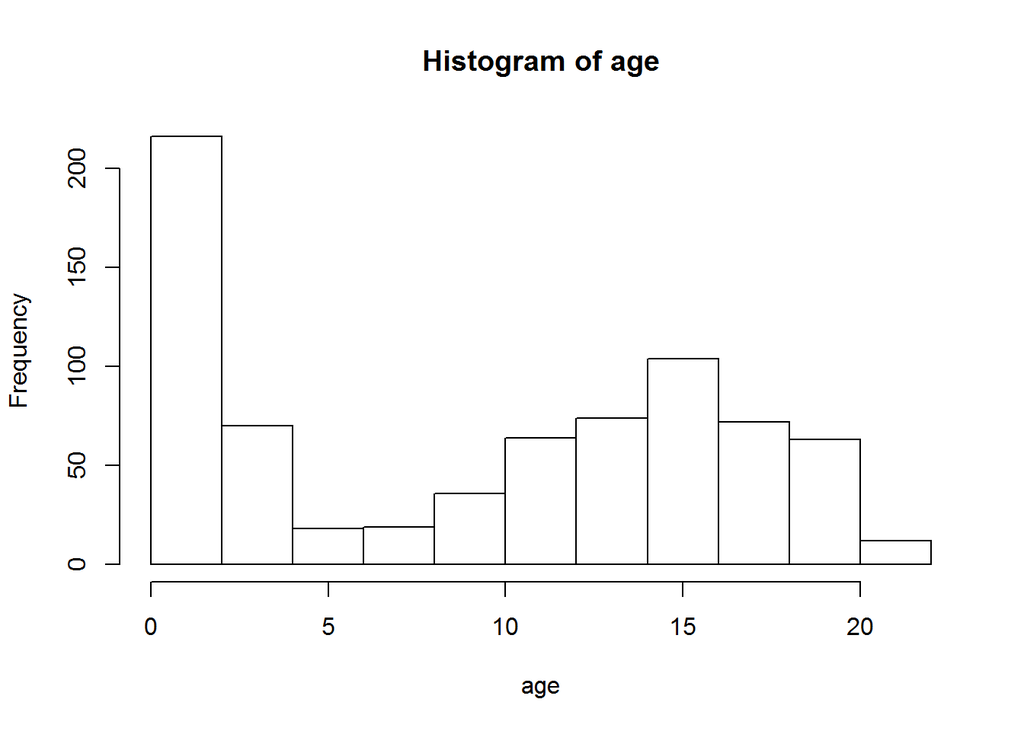

```r
boys %$%
  hist(age)
```

Using a pipe is a nice approach for this plot because it inherits the names of the objects we aim to plot. Without the pipe we might need to adjust the main title for the histogram:

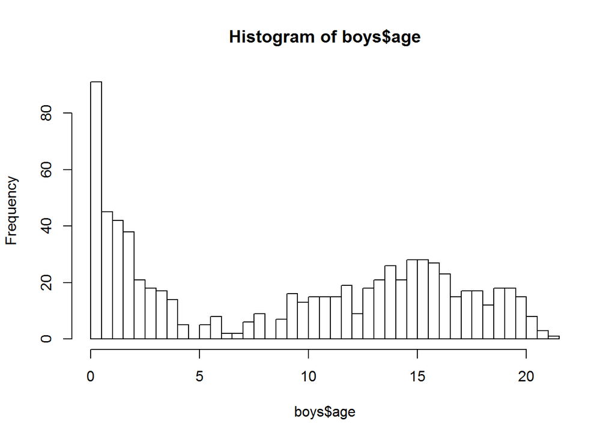

```r
hist(boys$age, breaks = 50)
```

4. **Create a bar chart for `reg` in the boys data set** With a standard plotting device in `R`:

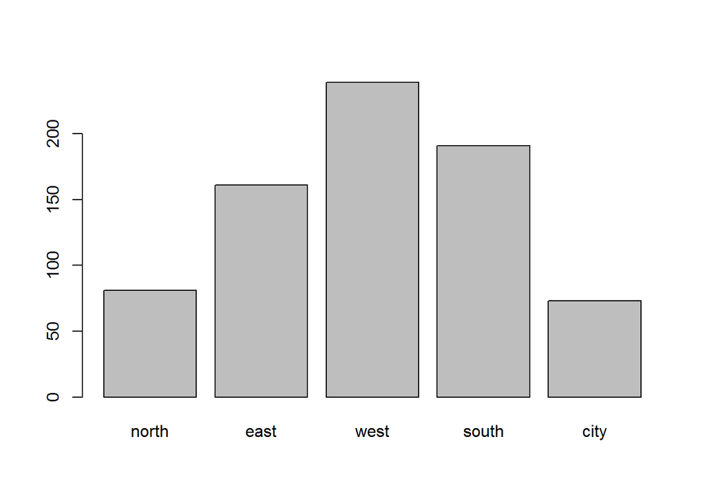

```r
boys %$%
  table(reg) %>%
  barplot()
```

5. **Create a box plot for `hgt` with different boxes for `reg` in the `boys` data set** With a standard plotting device in `R`:

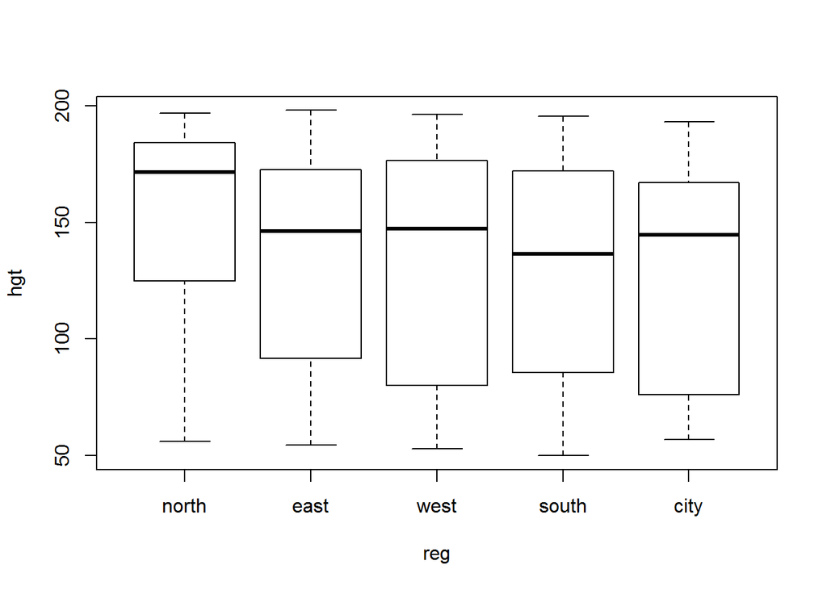

```r
boys %$%
  boxplot(hgt ~ reg)
```

6. **Read in the `sf` package, and open the shapefiles on the Danish municipalities from the course homepage. Plot the `REGIONNAVN` variable to see the Danish regions. Plot the municipal-level population**

```r
library(sf)
denmark <- st_read("DK_map.shp")
class(denmark)
```

```
## [1] "sf"         "data.frame"
```

The default plot for an object of class `sf` is a multi-plot of all attributes, up to a reasonable maximum:

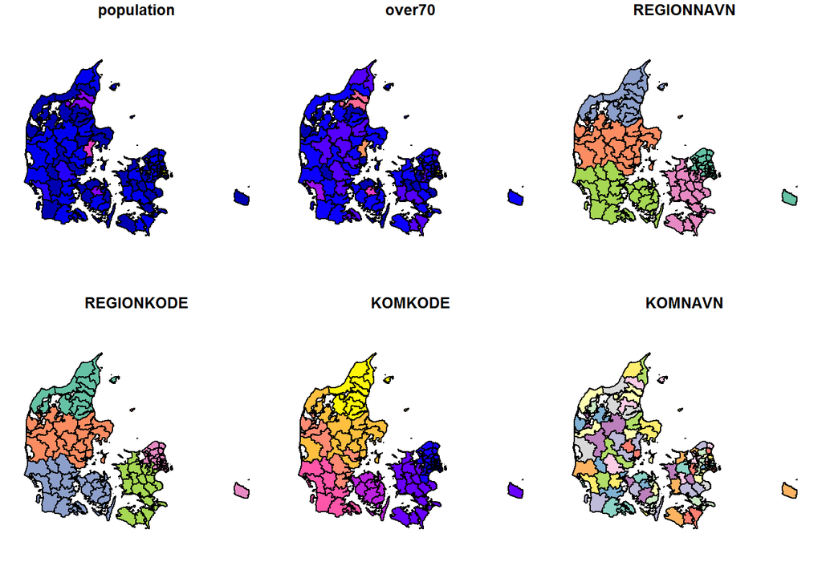

```r
plot(denmark)
```

If we want to view the shapes themselves without the attributes, we can plot the `st_geometry`

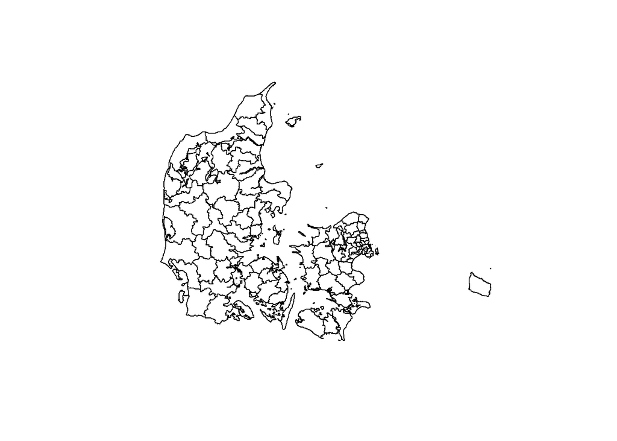

```r
plot(st_geometry(denmark))
```

Say we want to colour the maps by the administrative regions coded in the `REGIONNAVN` variable:

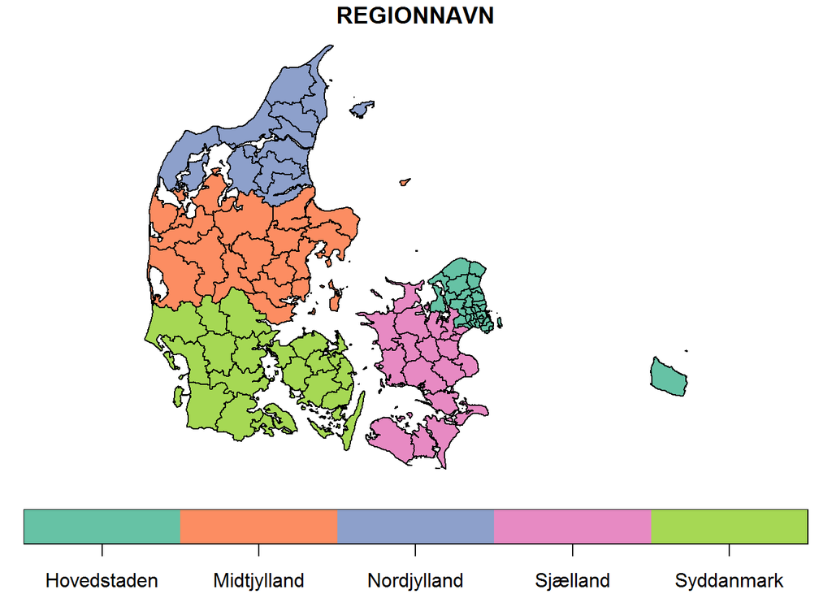

```r
denmark <- denmark %>% mutate( REGIONNAVN = word( REGIONNAVN , 2))
plot(denmark["REGIONNAVN"], key.pos = 1, key.length = 1)
```

The legend is being bothersome here, though. The `ggplot` default is prettier.

We plot the municipal-level population

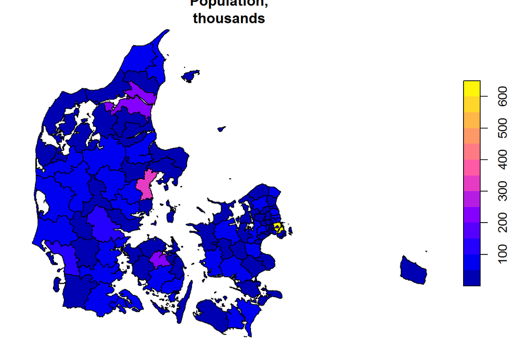

```r
denmark <- denmark %>% mutate( population = population/1000)

plot(denmark["population"], main = "Population,\nthousands")
```

But perhaps population per square kilometer might be more informative than just population

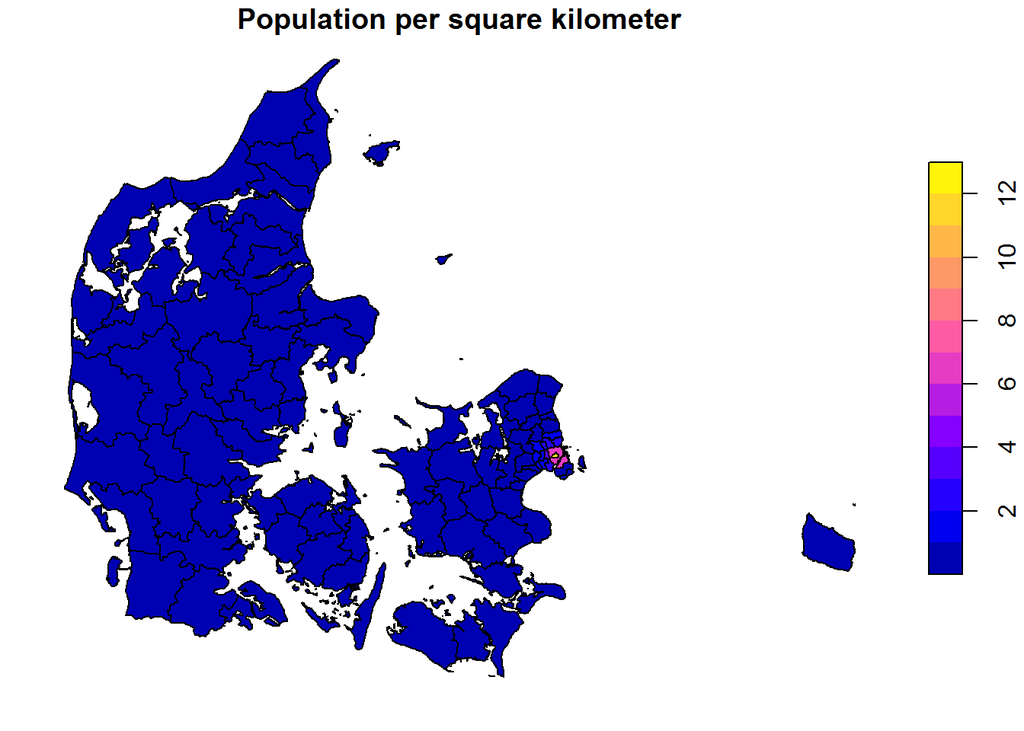

```r
denmark$area <- st_area(denmark)/(1000^2)

denmark1 <- denmark %>%
  group_by(KOMKODE) %>%
  summarise( total.area = sum( as.numeric( area ) ),
             population = first( population )) %>%
  mutate( pop.area = population/total.area)

plot(denmark1["pop.area"], main = "Population per square kilometer")
```

Our `sf` object contains more than one feature for some of the municipalities. The population number given is for the total municipality, so we need to compute the total area for each municipality.

End of Practical